# 7027HW2

# Q1

Load the dataset from HW2_house_dataset.csv. You will implement some treebased methods to predict housing prices. Basic characteristics of the dataset are given as follows: - Problem type: supervised learning, regression - Response variable: selling price of houses (in log10 units) - Data variable name in R: “price” - Number of features: 17 - Number of observations: 21,613 - Task: use house attributes to predict sale price of a house

## (1) Set seed

```r
hw2 <- read.csv("HW2_house_dataset.csv", header = TRUE)
hw2$condition = as.factor(hw2$condition)
head(hw2)
```

```
##   X    price bedrooms bathrooms sqft_living sqft_lot floors waterfront view
## 1 1 5.346157        3      1.00        1180     5650      1          0    0
## 2 2 5.730782        3      2.25        2570     7242      2          0    0
## 3 3 5.255273        2      1.00         770    10000      1          0    0
## 4 4 5.781037        4      3.00        1960     5000      1          0    0
## 5 5 5.707570        3      2.00        1680     8080      1          0    0
## 6 6 6.088136        4      4.50        5420   101930      1          0    0
##   condition sqft_above sqft_basement yr_built year_renovated zip_code lattitude
## 1   average       1180             0     1955           1955    98178   47.5112
## 2   average       2170           400     1951           1991    98125   47.7210
## 3   average        770             0     1933           1933    98028   47.7379
## 4 very_good       1050           910     1965           1965    98136   47.5208
## 5   average       1680             0     1987           1987    98074   47.6168
## 6   average       3890          1530     2001           2001    98053   47.6561
##   longitude nn_sqft_living nn_sqft_lot
## 1  -122.257           1340        5650
## 2  -122.319           1690        7639
## 3  -122.233           2720        8062
## 4  -122.393           1360        5000
## 5  -122.045           1800        7503
## 6  -122.005           4760      101930
```

```r
set.seed(123)
```

# (2) Perform stratified sampling, use 80% as training and 20% as testing. Do not touch the testing data until the last problem (6).

```r
trainIndex <- sample(nrow(hw2), 0.8 * nrow(hw2))

trainData <- hw2[trainIndex, ]
testData <- hw2[-trainIndex, ]
```

# (3) Perform random forest (RF) on the training data. Find the best tuning parameters and describe how you find them, and after that report the smallest cross-validated RMSE on the training data. Which four predictors are the most important? Obtain PDPs for these four predictors, describe them and provide possible explanations.

```r
n_features <- length(setdiff(names(trainData),"price"))
q3 <- ranger(
  price ~ .,
  data = trainData,
  mtry = floor(n_features/3),
  respect.unordered.factors = "order",
  seed = 123
)

default_rmse <- sqrt(q3$prediction.error)
```

```r
hyper_grid <- expand.grid(
  mtry = floor(n_features * c(0.05,0.15,0.25,0.333,0.4)),
  min.node.size = c(1,3,5,10),
  replace = c(TRUE,FALSE),
  sample.fraction = c(0.5,0.63,0.8),
  rmse = NA
)

for(i in seq_len(nrow(hyper_grid))){
  fit <- ranger(
    formula = price~.,
    data = trainData,
    num.trees = n_features * 10,
    mtry = hyper_grid$mtry[i],
    min.node.size = hyper_grid$min.node.size[i],
    replace = hyper_grid$replace[i],
    sample.fraction = hyper_grid$sample.fraction[i],
    verbose = FALSE,
    seed = 123,
    respect.unordered.factors = 'order',
  )
  hyper_grid$rmse[i] <- sqrt(fit$prediction.error)
}
hyper_grid %>%
  arrange(rmse) %>%
  mutate(perc_gain = (default_rmse - rmse)/default_rmse * 100)%>%
  head(1)
```

```
##   mtry min.node.size replace sample.fraction       rmse  perc_gain
## 1    7             5   FALSE            0.63 0.07893047 0.01225941
```

According to the result, mtry = 7, min.node.size = 5, replace = FALSE, sample.fraction = 0.63. The smallest rmse is 0.0789.

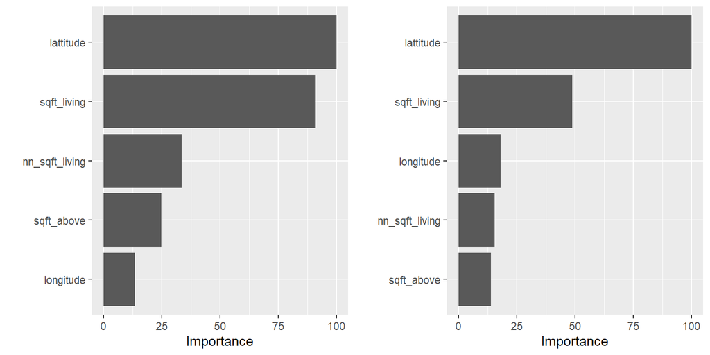

```r
q3_impurity <- ranger(
    formula = price~.,
    data = trainData,
    num.trees = n_features * 10,
    mtry = 7,
    min.node.size = 5,
    replace = FALSE,
    importance = 'impurity',
    sample.fraction = 0.63,
    verbose = FALSE,
    seed = 123,
    respect.unordered.factors = 'order',
  )

q3_permutation <- ranger(
    formula = price~.,
    data = trainData,
    num.trees = n_features * 10,
    mtry = 7,
    min.node.size = 5,
    replace = FALSE,
    importance = 'permutation',
    sample.fraction = 0.63,
    verbose = FALSE,
    seed = 123,
    respect.unordered.factors = 'order',
  )

p1 <- vip::vip(q3_impurity, num_features = 5, scale = TRUE)
p2 <- vip::vip(q3_permutation, num_features = 5, scale = TRUE)
gridExtra::grid.arrange(p1,p2,nrow = 1)
```

According to the result, the most four important predictors are lattitude, sqft_living, nn_sqft_livings and sqft_above.

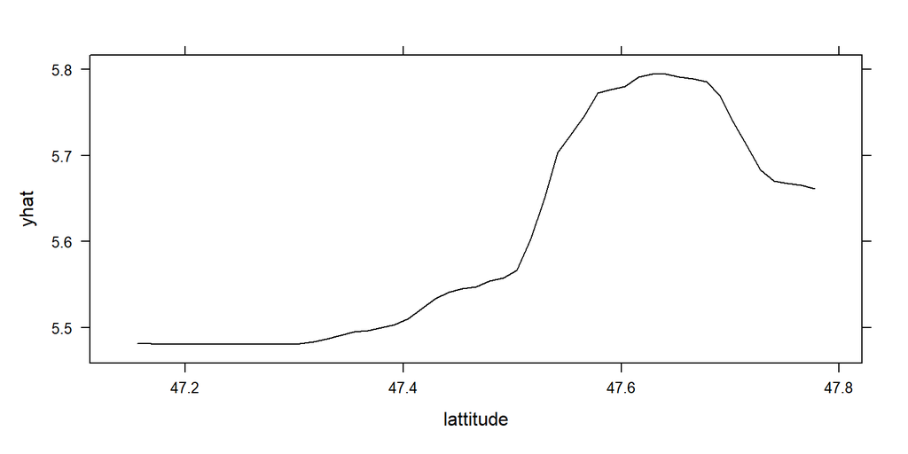

```r
partial(q3_impurity, pred.data = trainData, pred.var = "lattitude",plot = TRUE)
```

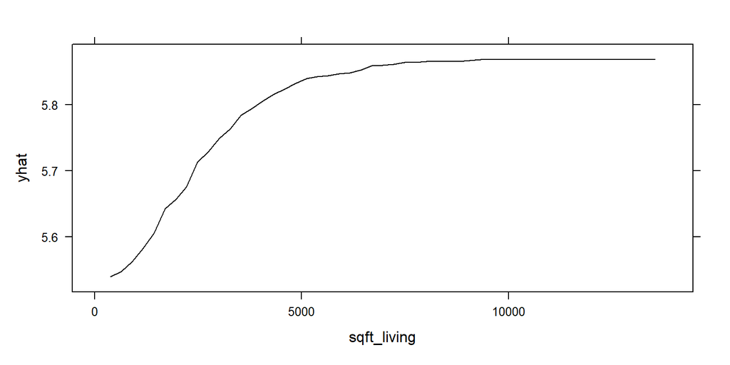

```r
partial(q3_impurity, pred.data = trainData, pred.var = "sqft_living",plot = TRUE)
```

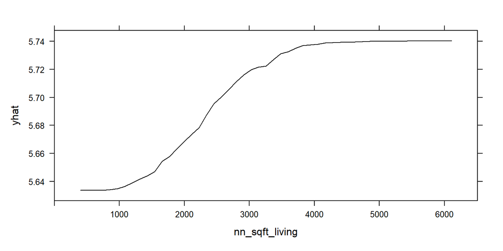

```r
partial(q3_impurity, pred.data = trainData, pred.var = "nn_sqft_living",plot = TRUE)
```

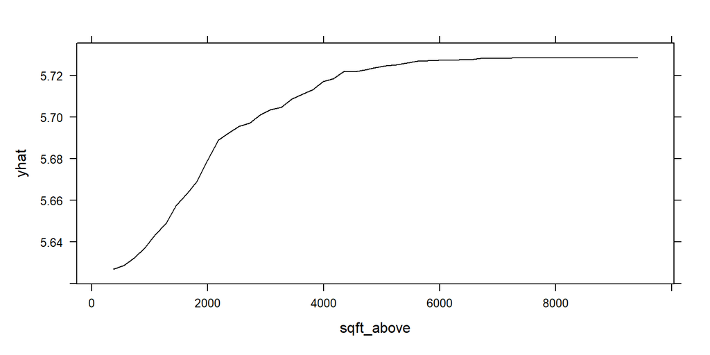

```r
partial(q3_impurity, pred.data = trainData, pred.var = "sqft_above",plot = TRUE)
```

# (4) Repeat (3) for basic GBM algorithm.

```r
hyper_grid <- expand.grid(
  shrinkage = c(0.001,0.01,0.1),
  depth = c(3,5),
  n = c(5,10),
  rmse = NA
)

for(i in seq_len(nrow(hyper_grid))){
  fit <- gbm(
    formula = price~.,
    data = trainData,
    distribution = "gaussian",
    n.trees = 5000,
    shrinkage = hyper_grid$shrinkage[i],
    interaction.depth = hyper_grid$depth[i],
    n.minobsinnode = hyper_grid$n[i],
    cv.folds = 10
  )
  best <- which.min(fit$cv.error)
  hyper_grid$rmse[i] <- sqrt(fit$cv.error[best])
}
hyper_grid = hyper_grid[order(hyper_grid$rmse),]
hyper_grid
```

```
##    shrinkage depth  n       rmse
## 11     0.010     5 10 0.07409246
## 9      0.100     3 10 0.07411177
## 12     0.100     5 10 0.07423444
## 6      0.100     5  5 0.07426200
## 5      0.010     5  5 0.07445145
## 3      0.100     3  5 0.07473668
## 8      0.010     3 10 0.07644408
## 2      0.010     3  5 0.07657455
## 10     0.001     5 10 0.09065535
## 4      0.001     5  5 0.09070042
## 1      0.001     3  5 0.09837595
## 7      0.001     3 10 0.09837971
```

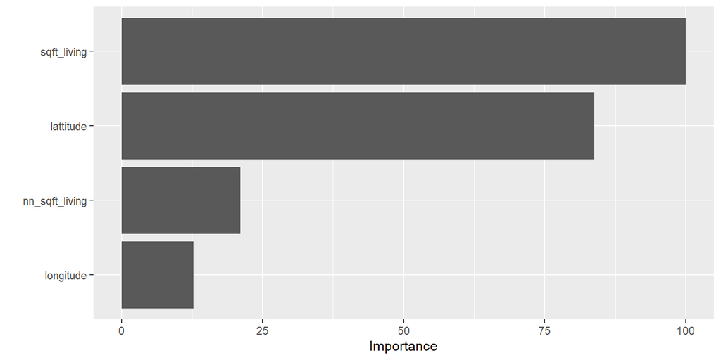

```r
gbm <- gbm(
    formula = price~.,
    data = trainData,
    distribution = "gaussian",
    n.trees = 5000,
    shrinkage = 0.1,
    interaction.depth = 5,
    n.minobsinnode = 10,
    cv.folds = 10
  )
p <- vip::vip(gbm,num_features=4,scale=TRUE)
grid.arrange(p)
```

According to the result, the most four important predictors are sqft_living, lattitude, nn_sqft_living and longitude.

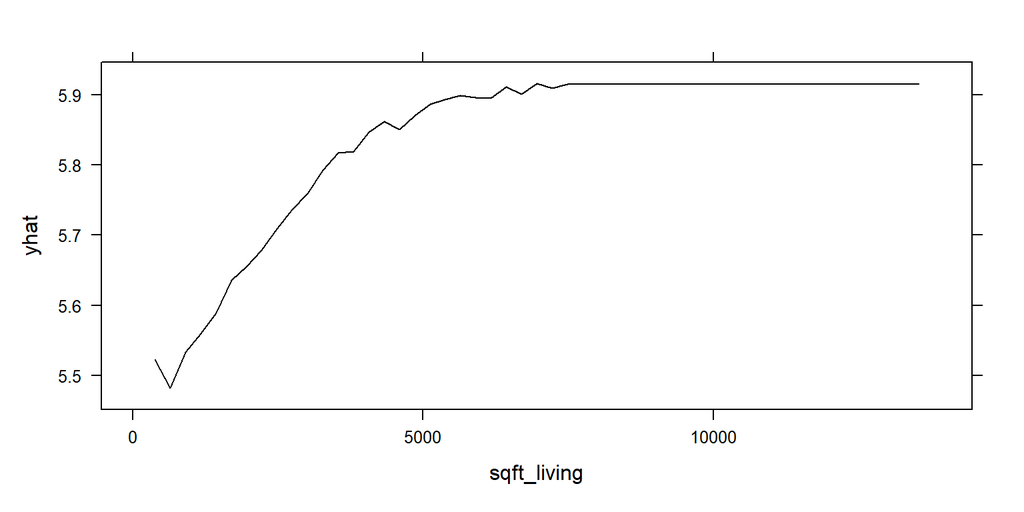

```r
gbmfunc <- function(object,newdata){
  results=mean(predict(object,newdata,n.trees=1336))
  return(results)
}
partial(gbm, pred.data = trainData, pred.var = "sqft_living",pred.fun = gbmfunc,plot = TRUE,recursive = FALSE)
```

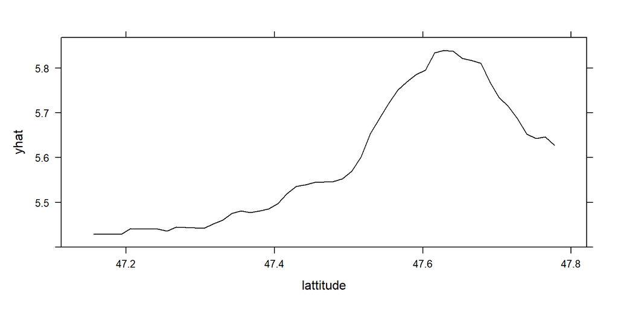

```r
partial(gbm, pred.data = trainData, pred.var = "lattitude",pred.fun = gbmfunc,plot = TRUE,recursive = FALSE)
```

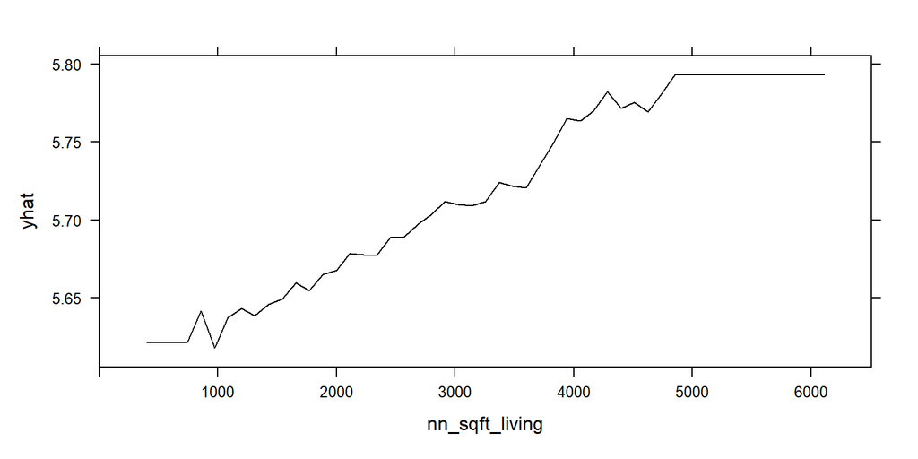

```r
partial(gbm, pred.data = trainData, pred.var = "nn_sqft_living",pred.fun = gbmfunc,plot = TRUE,recursive = FALSE)
```

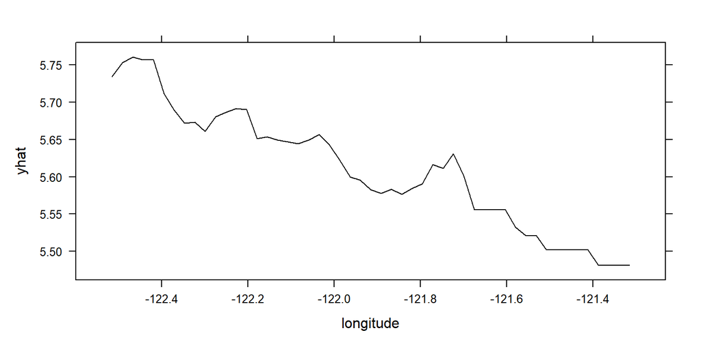

```r
partial(gbm, pred.data = trainData, pred.var = "longitude",pred.fun = gbmfunc,plot = TRUE,recursive = FALSE)
```

nn_sqft_living: The PDP and possible reason is similar to sqft_living.

# (5) Are the four most important variables different in (3)-(4)?

The most four important predictors in RF are lattitude, sqft_living, nn_sqft_livings and sqft_above. While in GBM are sqft_living, lattitude, nn_sqft_living and longitude. Relatively the diference between them are little.

# (6) Among RF and GBM with their own best-tuning parameters, which one has the smallest crossvalidated RMSE on the training data? Choose that method, refit the model with all of the training data, use that model to make prediction on the testing data, report the RMSE for the testing data. Is the obtained RMSE smaller or larger than the cross-validated RMSE?

```r
prediction <- predict(gbm, newdata = testData)
```

```
## Using 1364 trees...
```

```r
rmse <- sqrt(mean((prediction - testData$price)^2))
rmse
```

```
## [1] 0.07517279
```

It is larger than the cross-validated RMSE.